# BostonHomes

Jacky/Dottie Maya

11/15/2019

Use a neural net to identify/predict median home prices in the Boston area. Data are from a study done a number of years ago. Data are in the MASS package. Listed below are the variable names and descriptions in the Boston data set.

full description: https://www.r-bloggers.com/fitting-a-neural-network-in-r-neuralnet-package/

import data

```r
set.seed(500)
library(MASS)
data <- Boston
head(data,3)
```

```
##      crim zn indus chas   nox    rm  age    dis rad tax ptratio  black
## 1 0.00632 18  2.31    0 0.538 6.575 65.2 4.0900   1 296    15.3 396.90
## 2 0.02731  0  7.07    0 0.469 6.421 78.9 4.9671   2 242    17.8 396.90
## 3 0.02729  0  7.07    0 0.469 7.185 61.1 4.9671   2 242    17.8 392.83
##   lstat medv
## 1  4.98 24.0
## 2  9.14 21.6
## 3  4.03 34.7
```

check for “NA” entries in the data frame.. count how many, and then drop any row with NA’s in it.

```r
apply(data,2,function(x) sum(is.na(x)))
```

```
##    crim      zn   indus    chas     nox      rm     age     dis     rad
##       0       0       0       0       0       0       0       0       0
##     tax ptratio   black   lstat    medv
##       0       0       0       0       0
```

since there were no NA’s proceed  
### help(Boston)

varibles in the data frame are:

```
crim    :  per capita crime rate by town.

zn      :  proportion of residential land zoned for lots over 25,000 sq.ft.

indus   : proportion of non-retail business acres per town.

chas    : Charles River dummy variable (= 1 if tract bounds river;
       0 otherwise).

nox     : nitrogen oxides concentration (parts per 10 million).

rm      : average number of rooms per dwelling.

age     : proportion of owner-occupied units built prior to 1940.

dis     : weighted mean of distances to five Boston employment
        centres.

rad     : index of accessibility to radial highways.

tax     : full-value property-tax rate per $10,000.

ptratio : pupil-teacher ratio by town.

black   : 1000(Bk - 0.63)^2 where Bk is
         the proportion of black residents by town.

lstat   : lower status of the population (percent).

medv    : median value of owner-occupied homes in $1000s.
```

### First order of business..

speed matters up by identifying variables that are likely predictors of medv

**lm** is an R function to estemate a linear model (linear regression)– which coefficients are different from 0?

Fit a linear model based on the entire data set

```r
lm.fit <- glm(medv~., data=Boston)
summary(lm.fit)
```

```
##
## Call:
## glm(formula = medv ~ ., data = Boston)
##
## Deviance Residuals:
##     Min       1Q   Median       3Q      Max
## -15.595   -2.730   -0.518    1.777   26.199
##
## Coefficients:
##               Estimate Std. Error t value Pr(>|t|)
## (Intercept)  3.646e+01  5.103e+00   7.144 3.28e-12 ***
## crim        -1.080e-01  3.286e-02  -3.287 0.001087 **
## zn           4.642e-02  1.373e-02   3.382 0.000778 ***
## indus        2.056e-02  6.150e-02   0.334 0.738288
## chas         2.687e+00  8.616e-01   3.118 0.001925 **
## nox         -1.777e+01  3.820e+00  -4.651 4.25e-06 ***
## rm           3.810e+00  4.179e-01   9.116  < 2e-16 ***
## age          6.922e-04  1.321e-02   0.052 0.958229
## dis         -1.476e+00  1.995e-01  -7.398 6.01e-13 ***
## rad          3.060e-01  6.635e-02   4.613 5.07e-06 ***
## tax         -1.233e-02  3.760e-03  -3.280 0.001112 **
## ptratio     -9.527e-01  1.308e-01  -7.283 1.31e-12 ***
## black        9.312e-03  2.686e-03   3.467 0.000573 ***
## lstat       -5.248e-01  5.072e-02 -10.347  < 2e-16 ***
## ---
## Signif. codes:  0 '***' 0.001 '**' 0.01 '*' 0.05 '.' 0.1 ' ' 1
##
## (Dispersion parameter for gaussian family taken to be 22.51785)
##
##     Null deviance: 42716  on 505  degrees of freedom
## Residual deviance: 11079  on 492  degrees of freedom
## AIC: 3027.6
##
## Number of Fisher Scoring iterations: 2
```

notice that the linear fit suggests we can discard variables indus, age; hence drop indus and age from the data set

function select from dplyr

```r
dataNew = dplyr::select(data,-c(indus, age))
```

set up a random index, selecting 70% of the data set for training, balance for testing

try running this chunk a few times… **sample** takes a random sample of the row numbers, then uses those rows for the training set, and the balance of the data for the test set

```r
index <- sample(1:nrow(dataNew),round(0.70*nrow(dataNew)))
train <- dataNew[index,]

# everyting else (rows) not in the training set is in the test set
test <- dataNew[-index,]

#refit the linear model, how does it look

lm.fit <- glm(medv~., data=train)
summary(lm.fit)
```

```
##
## Call:
## glm(formula = medv ~ ., data = train)
##
## Deviance Residuals:
##      Min        1Q    Median        3Q       Max
## -15.4205   -2.5822   -0.5649    1.8389   29.0211
##
## Coefficients:
##               Estimate Std. Error t value Pr(>|t|)
## (Intercept)  31.718607   5.668910   5.595 4.52e-08 ***
## crim         -0.123385   0.037512  -3.289 0.001109 **
## zn            0.046851   0.014469   3.238 0.001322 **
## chas          1.796861   1.007241   1.784 0.075319 .
## nox         -20.684533   4.408027  -4.692 3.91e-06 ***
## rm            4.749030   0.483342   9.825  < 2e-16 ***
## dis          -1.568341   0.215148  -7.290 2.17e-12 ***
## rad           0.303211   0.071284   4.254 2.72e-05 ***
## tax          -0.013256   0.003719  -3.565 0.000416 ***
## ptratio      -0.964085   0.145931  -6.606 1.51e-10 ***
## black         0.009971   0.003047   3.273 0.001174 **
## lstat        -0.403304   0.058509  -6.893 2.64e-11 ***
## ---
## Signif. codes:  0 '***' 0.001 '**' 0.01 '*' 0.05 '.' 0.1 ' ' 1
##
## (Dispersion parameter for gaussian family taken to be 20.58107)
##
##     Null deviance: 30674.9  on 353  degrees of freedom
## Residual deviance:  7038.7  on 342  degrees of freedom
## AIC: 2089
##
## Number of Fisher Scoring iterations: 2
```

### and test the model based on the test set

```r
pr.lm <- predict(lm.fit,test)
#mean square error of the predictions
MSE.lm <- sum((pr.lm - test$medv)^2)/nrow(test)
```

Scale the set for a NN- Notice this scales every variable. This is done to eliminate the influence of units (for example, distance in nano-meters or megaparasecs?)

train_ and test_ are the data frames of scaled data

```r
maxs <- apply(dataNew, 2, max)
mins <- apply(dataNew, 2, min)
scaled <- as.data.frame(scale(dataNew, center = mins, scale = maxs - mins))
train_ <- scaled[index,]
test_ <- scaled[-index,]
```

### set up a neural net

first fit a linear model; we’ll compare this to a neural net result

```r
library(neuralnet)
n <- names(train_)
f <- as.formula(paste("medv ~", paste(n[!n %in% "medv"],
            collapse = " + ")))
lm.fit1 <- glm(medv~., data=train)
summary(lm.fit)
```

```
##
## Call:
## glm(formula = medv ~ ., data = train)
##
## Deviance Residuals:
##      Min        1Q    Median        3Q       Max
## -15.4205   -2.5822   -0.5649    1.8389   29.0211
##
## Coefficients:
##               Estimate Std. Error t value Pr(>|t|)
## (Intercept)  31.718607   5.668910   5.595 4.52e-08 ***
## crim         -0.123385   0.037512  -3.289 0.001109 **
## zn            0.046851   0.014469   3.238 0.001322 **
## chas          1.796861   1.007241   1.784 0.075319 .
## nox         -20.684533   4.408027  -4.692 3.91e-06 ***
## rm            4.749030   0.483342   9.825  < 2e-16 ***
## dis          -1.568341   0.215148  -7.290 2.17e-12 ***
## rad           0.303211   0.071284   4.254 2.72e-05 ***
## tax          -0.013256   0.003719  -3.565 0.000416 ***
## ptratio      -0.964085   0.145931  -6.606 1.51e-10 ***
## black         0.009971   0.003047   3.273 0.001174 **
## lstat        -0.403304   0.058509  -6.893 2.64e-11 ***
## ---
## Signif. codes:  0 '***' 0.001 '**' 0.01 '*' 0.05 '.' 0.1 ' ' 1
##
## (Dispersion parameter for gaussian family taken to be 20.58107)
##
##     Null deviance: 30674.9  on 353  degrees of freedom
## Residual deviance:  7038.7  on 342  degrees of freedom
## AIC: 2089
##
## Number of Fisher Scoring iterations: 2
```

### ASIDE: example to show what’s going on..

```r
nnEG <- neuralnet(medv ~ crim+nox+rm, data=train_, hidden=c(2,2) ,linear.output=TRUE)
```

plot ..

```r
plot(nnEG)
```

[output not shown]

```r
pr.nnEG = compute(nnEG, test_)
pr.nnEG_ <- pr.nnEG$net.result*(max(data$medv)-min(data$medv))+min(data$medv)
test.r <- (test_$medv)*(max(data$medv)-min(data$medv))+min(data$medv)
MSE.nnEG <- sum((test.r - pr.nnEG_)^2)/nrow(test_)

print(paste('MSE of the Example NN ',round(MSE.nnEG,2)))
```

```
## [1] "MSE of the Example NN  35.8"
```

## back to the original NN evaluate

two hidden layers, first with 5 nodes, second with 3 nodes Where did the number of layers, nodes come from?

```r
nn = neuralnet(f,data=train_,hidden=c(5,3),linear.output=T)
```

```r
#pr.nn <- compute(nn,test_[1:13,])
pr.nn = compute(nn, test_)
pr.nn_ <- pr.nn$net.result*(max(data$medv)-min(data$medv))+min(data$medv)
test.r <- (test_$medv)*(max(data$medv)-min(data$medv))+min(data$medv)
MSE.nn <- sum((test.r - pr.nn_)^2)/nrow(test_)

print(paste('MSE of linear model: ',round(MSE.lm,2),'  MSE of the NN ',round(MSE.nn,2)))
```

```
## [1] "MSE of linear model:  28.25   MSE of the NN  18.43"
```

## Plot some results

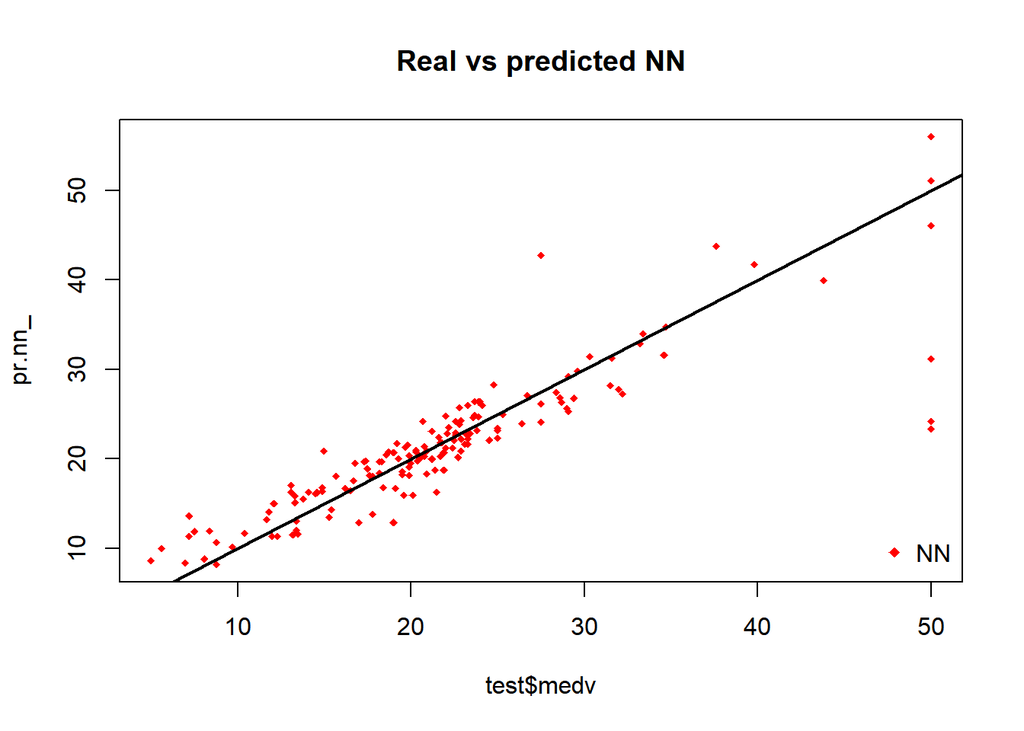

```r
#par(mfrow=c(1,2))
plot(test$medv,pr.nn_,col='red',main='Real vs predicted NN',pch=18,cex=0.7)
abline(0,1,lwd=2)
legend('bottomright',legend='NN',pch=18,col='red', bty='n')
```

### and the linear model:

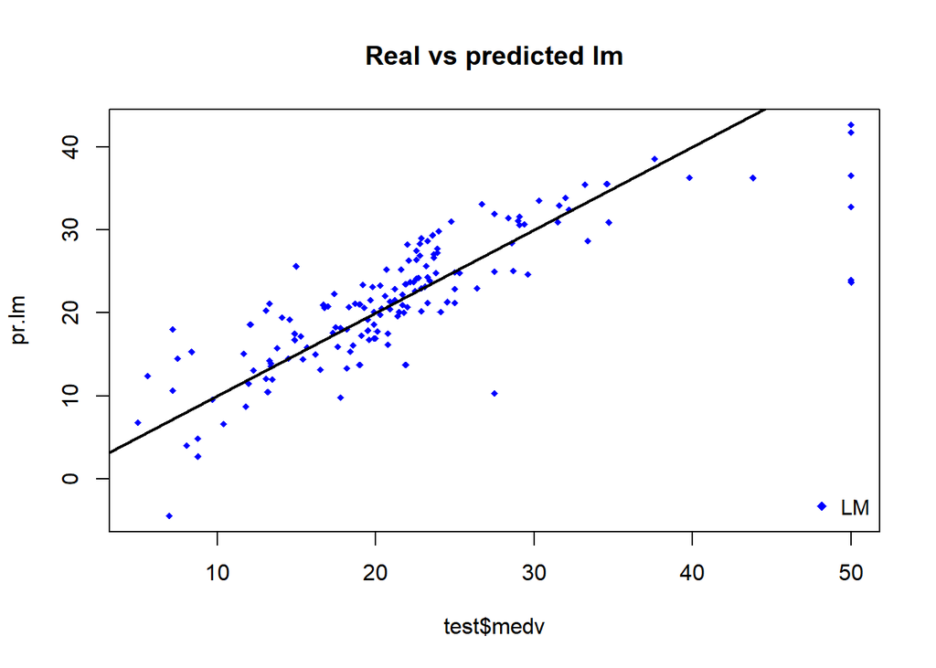

```r
plot(test$medv,pr.lm,col='blue',main='Real vs predicted lm',pch=18, cex=0.7)
abline(0,1,lwd=2)
legend('bottomright',legend='LM',pch=18,col='blue', bty='n', cex=.95)
```

### both on one graph

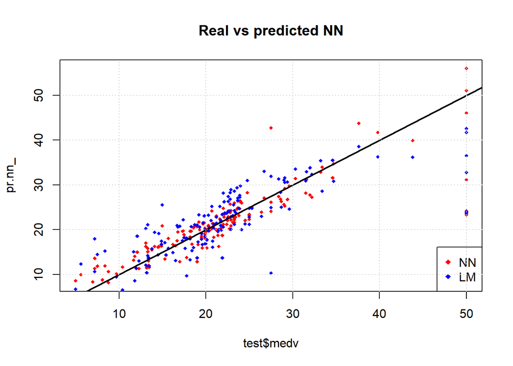

```r
plot(test$medv,pr.nn_,col='red',main='Real vs predicted NN',pch=18,cex=0.7)
points(test$medv,pr.lm,col='blue',pch=18,cex=0.7)
abline(0,1,lwd=2)
legend('bottomright',legend=c('NN','LM'),pch=18,col=c('red','blue'))
grid()
```

## Evaluate the NN

```r
library(boot)  # bootstrap for errors

set.seed(200)
lm.fit <- glm(medv~.,data=dataNew)

#cross validation...
#cv.glm is the cross validation for GLM

k=170
cv.glm(dataNew,lm.fit,K=k)$delta[1]
```

```
## [1] 23.56935
```

```r
set.seed(450)
#cv.error is the error estimated by cross validation

cv.error <- NULL
# k iterations

#library(plyr) # need this to get the progress bar
# pbar <- create_progress_bar('text')
# pbar$init(k)

# notice using 90% of the data for a fit, not 70%
for(i in 1:k){
    # use more of the data, but mix it up...
    index <- sample(1:nrow(dataNew),round(0.9*nrow(dataNew)))
    train.cv <- scaled[index,]
    test.cv <- scaled[-index,]
    nn <- neuralnet(f,data=train.cv,hidden=c(5,3),linear.output=T)

    #    pr.nn <- compute(nn,test.cv[1:13,])
    pr.nn = compute(nn, test.cv)
    pr.nn <- pr.nn$net.result*(max(data$medv)-min(data$medv))+min(data$medv)
    test.cv.r <- (test.cv$medv)*(max(data$medv)-min(data$medv))+min(data$medv)
    cv.error[i] <- sum((test.cv.r - pr.nn)^2)/nrow(test.cv)
#    pbar$step()
}

mean(cv.error)
```

```
## [1] 13.07217
```

```r
summary(cv.error)
```

[output not shown]

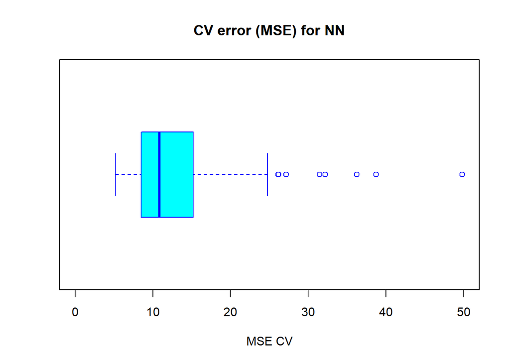

```r
boxplot(cv.error,xlab='MSE CV',col='cyan',
        border='blue',names='CV error (MSE)',ylim=c(0,50),
        main='CV error (MSE) for NN',horizontal=TRUE)
```

Histogram of the cross-validation errors

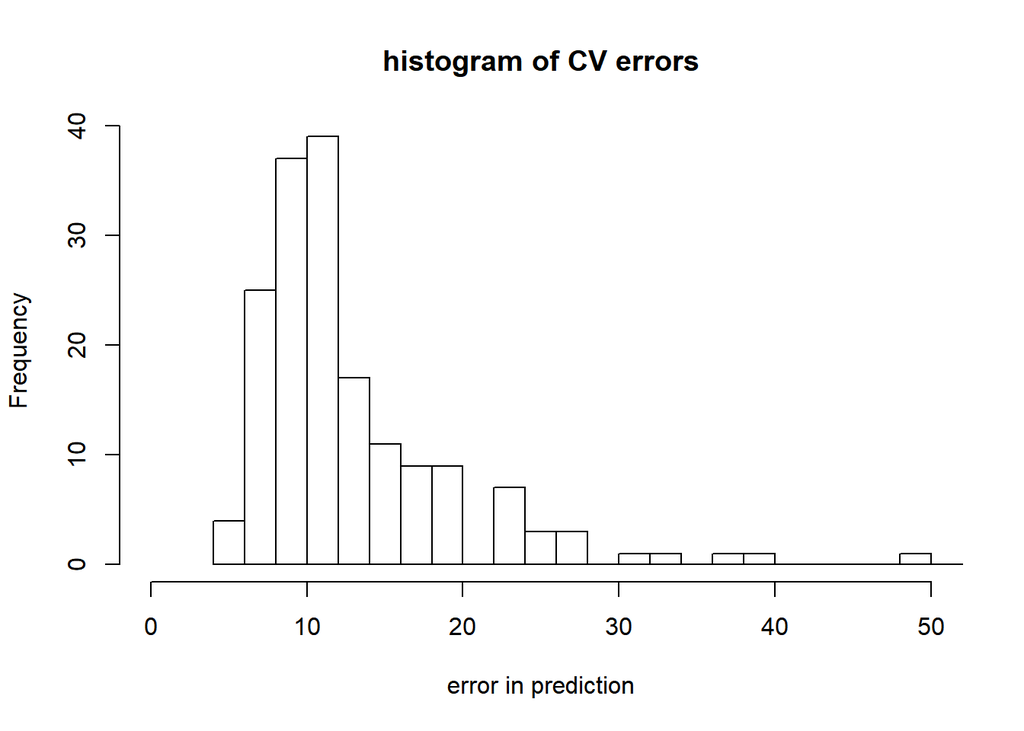

```r
hist(cv.error, main='histogram of CV errors', xlab='error in prediction', xlim=c(0,50), breaks=20)
```

90% prediction CI

```r
cvErrorSort = sort(cv.error)
LCIindex = floor(0.05*k)
UCIindex = ceiling(0.95*k)
print(paste('90% CI = (', round(cvErrorSort[LCIindex],2),' , ', round(cvErrorSort[UCIindex],2),')'))
```

```
## [1] "90% CI = ( 6.54  ,  26.11 )"
```

```r
# use R functions to get the median and perentile values
print(paste('median error: ',round(median(cvErrorSort),2)))
```

```
## [1] "median error:  10.84"
```

```r
print(quantile(cv.error, probs=c(0.95, 0.9, 0.5, 0.10, 0.05)))
```

```
##       95%       90%       50%       10%        5%
## 25.504054 22.352176 10.842086  7.367075  6.566431
```